# Dashboard Autoritarismo e Inseguridad - Perú 2023

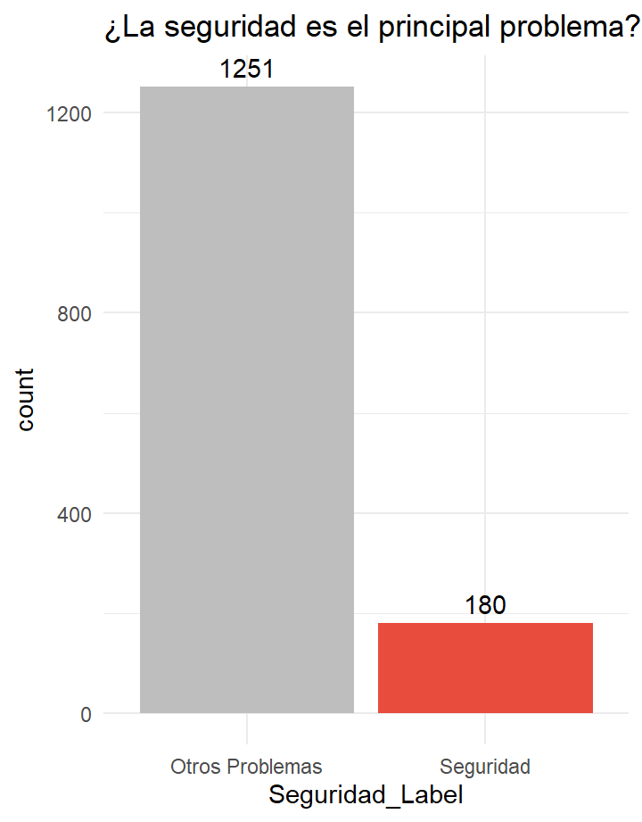

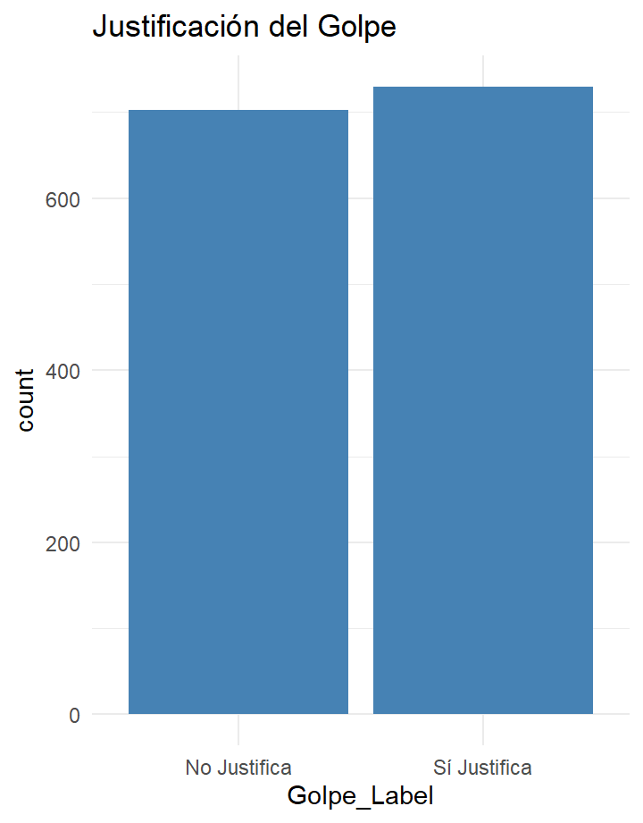

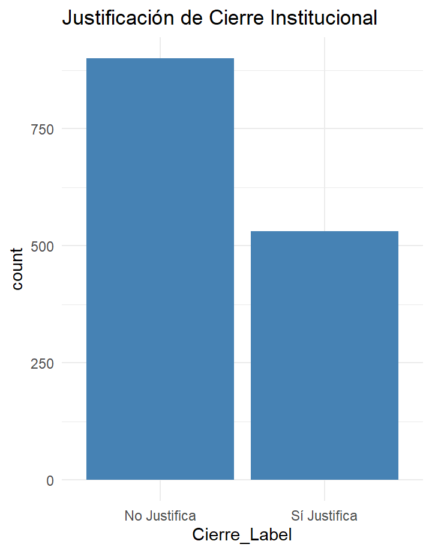

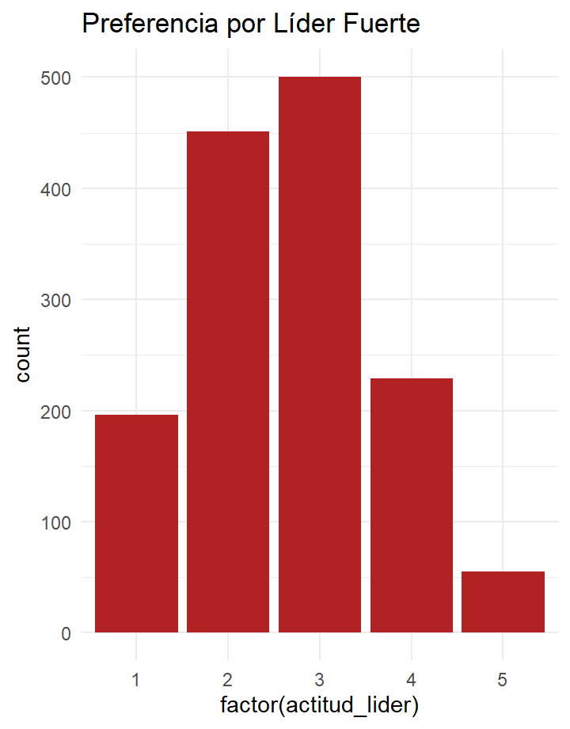

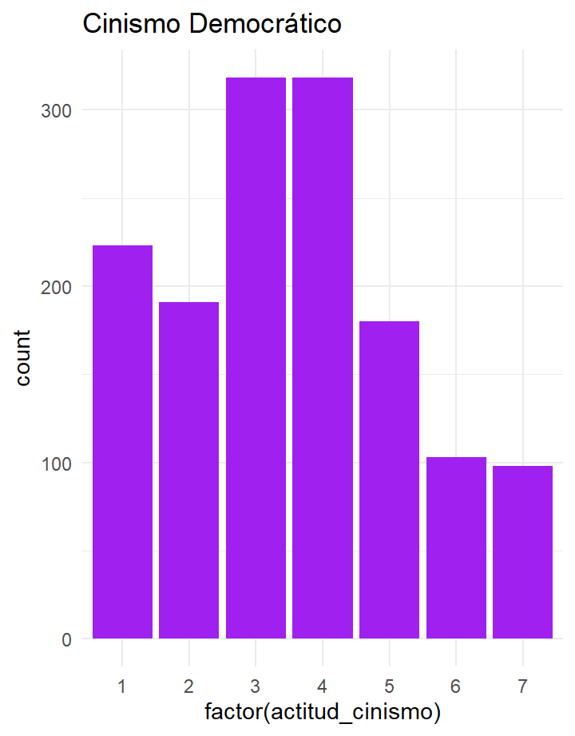

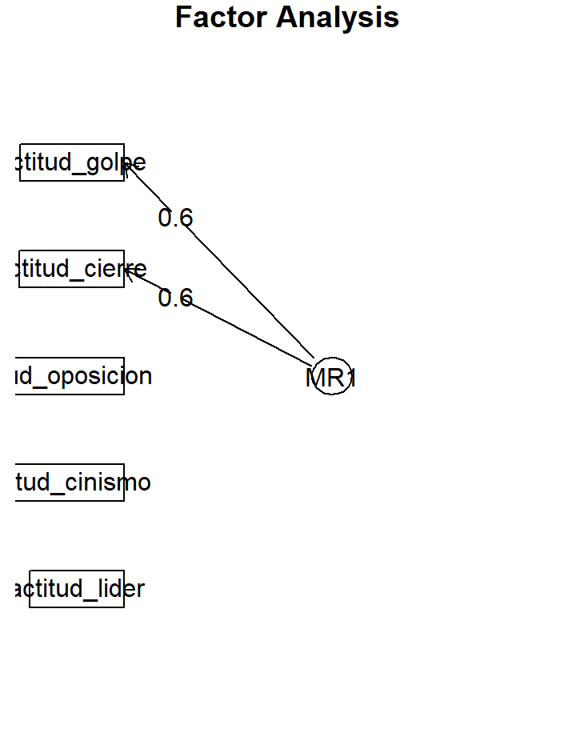

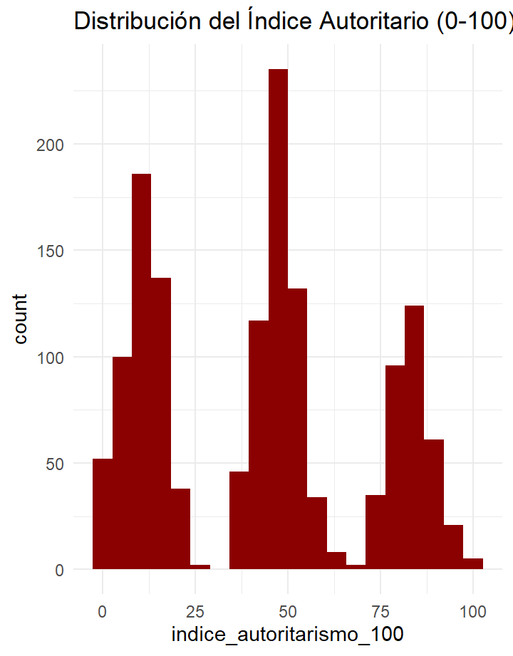

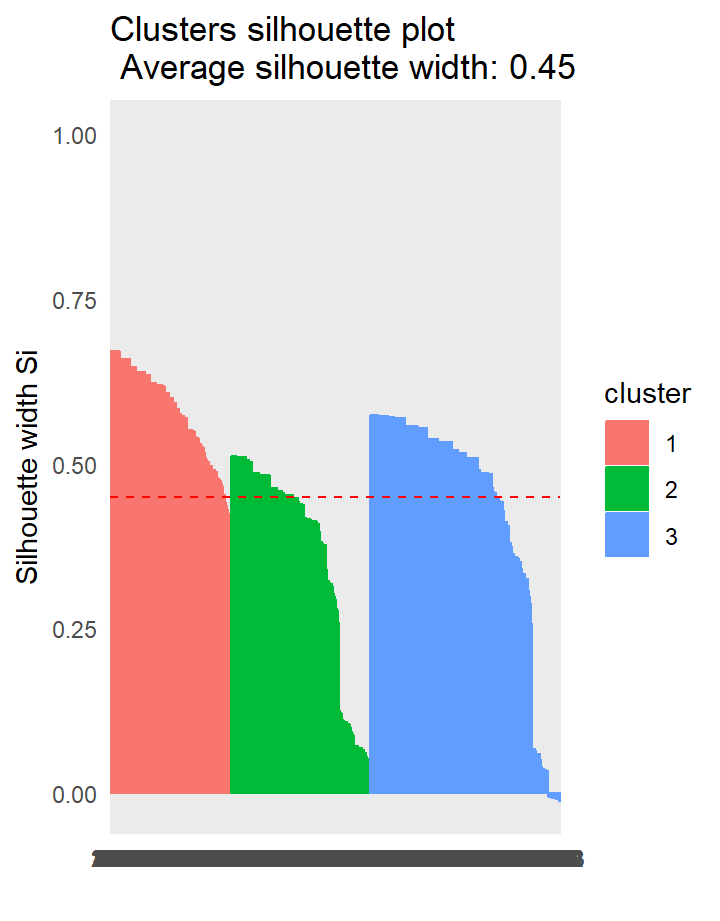

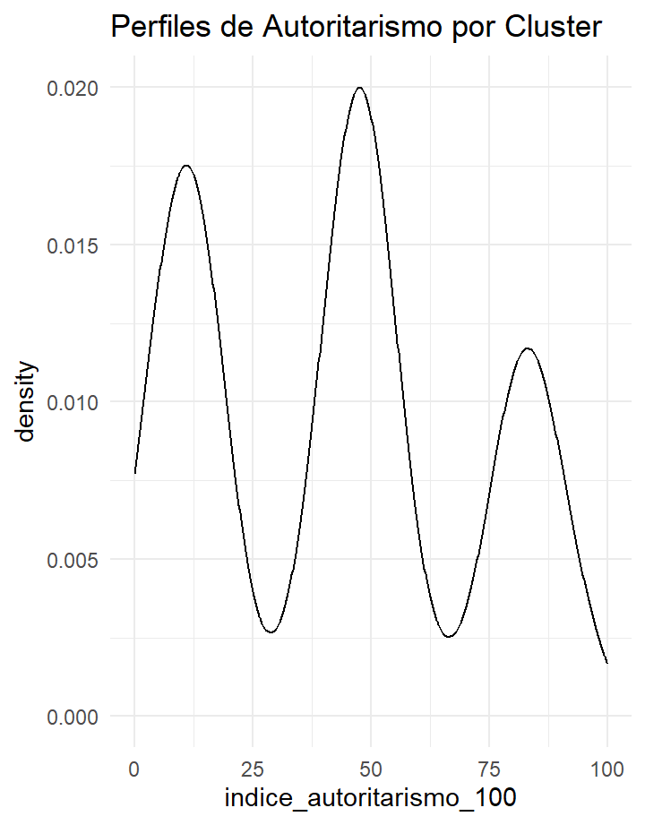

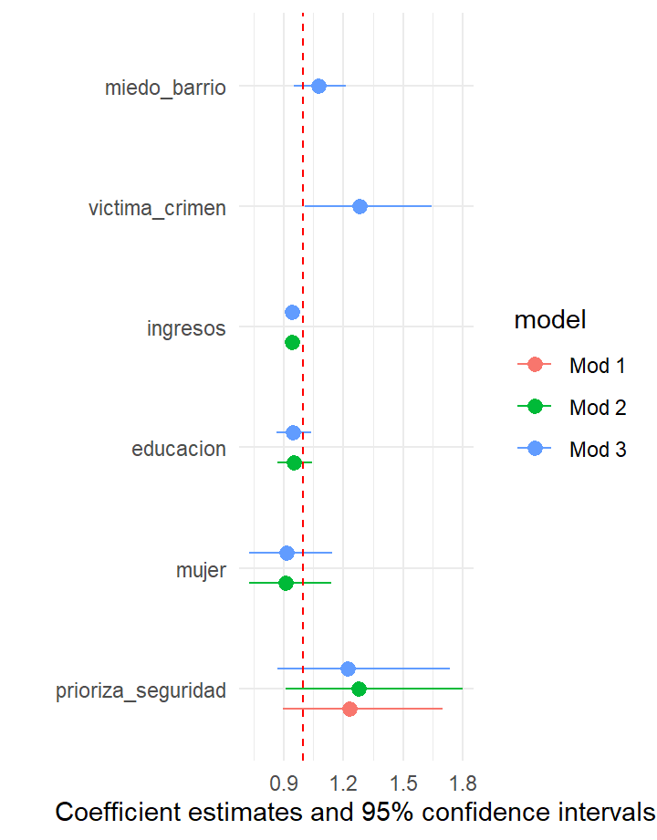

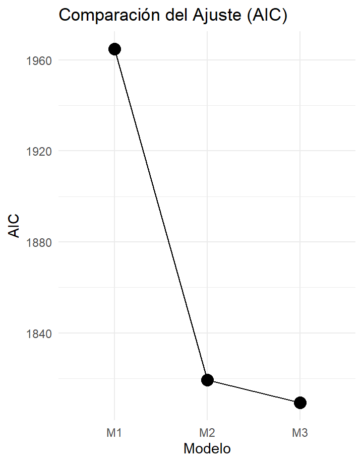

# 0. Presentación

### **Introducción al Estudio**

**Contexto**

El Perú enfrenta una crisis de seguridad ciudadana que ha posicionado a la delincuencia como una preocupación central. La teoría política sugiere que, ante amenazas graves, la ciudadanía podría estar dispuesta a sacrificar libertades democráticas a cambio de orden (“Mano Dura”).

**Pregunta de Investigación**

> *¿La priorización de la seguridad como el principal problema del país aumenta la probabilidad de que un ciudadano adopte actitudes autoritarias?*

**Metodología**

Analizamos datos de la encuesta **LAPOP 2023**. Utilizamos un enfoque mixto que incluye: 1. **Análisis Factorial (EFA):** Para construir un Índice de Autoritarismo robusto (0-100). 2. **Clusterización (PAM):** Para identificar perfiles de ciudadanos. 3. **Regresión Logística:** Para testear estadísticamente la hipótesis.

### **Conclusiones Principales**

**Hallazgos Clave**

Tras el análisis estadístico, encontramos evidencia que desafía el sentido común:

1. **El miedo abstracto no predice autoritarismo:** La variable `prioriza_seguridad` no resultó estadísticamente significativa en los modelos multivariados. Esto indica que simplemente *creer* que la seguridad es el problema principal no vuelve a una persona autoritaria automáticamente.
2. **La experiencia directa es el detonante:** Lo que sí predice el autoritarismo es la **victimización real**. Haber sido víctima de un delito aumenta significativamente la probabilidad de apoyar medidas de fuerza (Odds Ratio > 1).
3. **Sociedad Polarizada:** El análisis de clusters revela que no todos somos iguales. Existe un grupo “Núcleo Autoritario” (aprox. 25% de la muestra) que apoya abiertamente golpes militares, mientras que un grupo “Demócrata” rechaza estas medidas a pesar de la inseguridad.

**Implicancia**

La demanda de mano dura en Perú no parece ser un fenómeno puramente ideológico, sino una reacción defensiva ante la vulnerabilidad física (victimización) y material.

**Autoras:** Ana Paula y Dominike

**Curso:** Estadística para el Análisis Político 2

**Fuente de Datos:** Barómetro de las Américas (LAPOP) 2023

# 1. Análisis Univariado

### **Distribución del problema principal (Seguridad)**

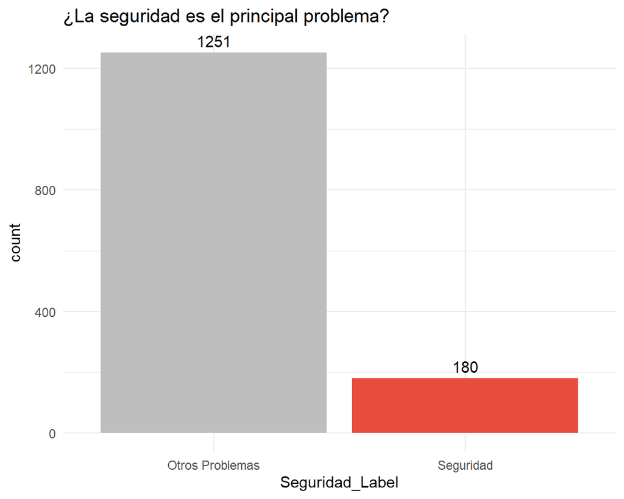

### **Tabla de Frecuencias**

Priorización de la Seguridad

| Seguridad_Label | n | Porcentaje |
| --- | --- | --- |
| Otros Problemas | 1251 | 87.4% |
| Seguridad | 180 | 12.6% |

## Actitudes Autoritarias

### **Golpe Militar**

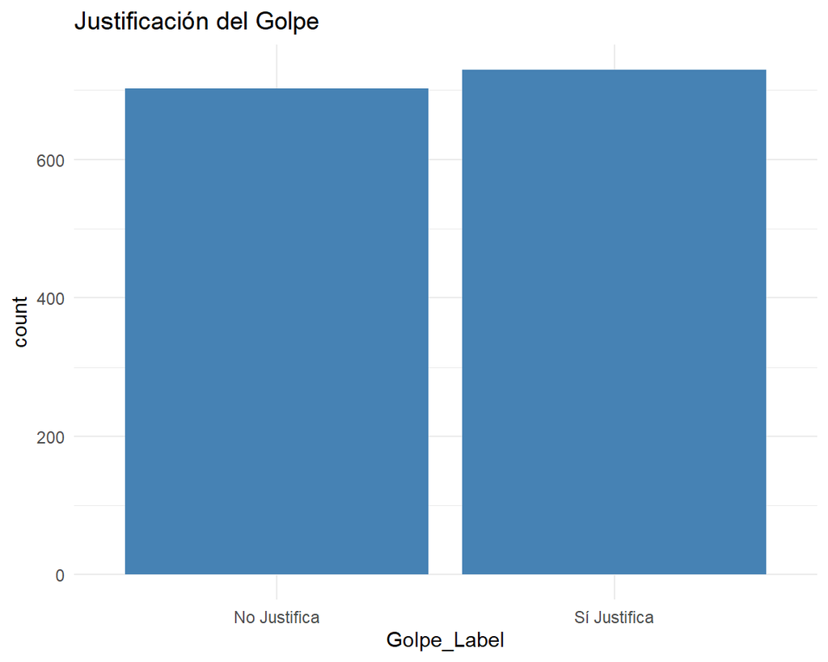

### **Cierre del Congreso**

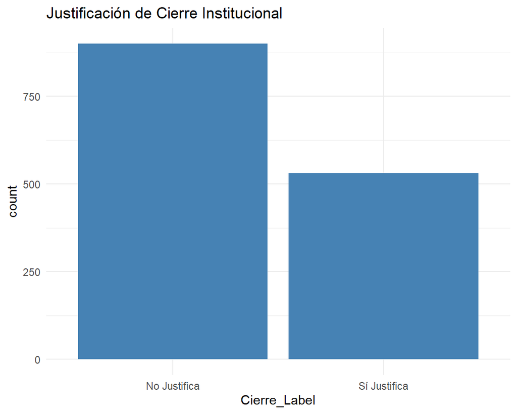

### **Líder Fuerte**

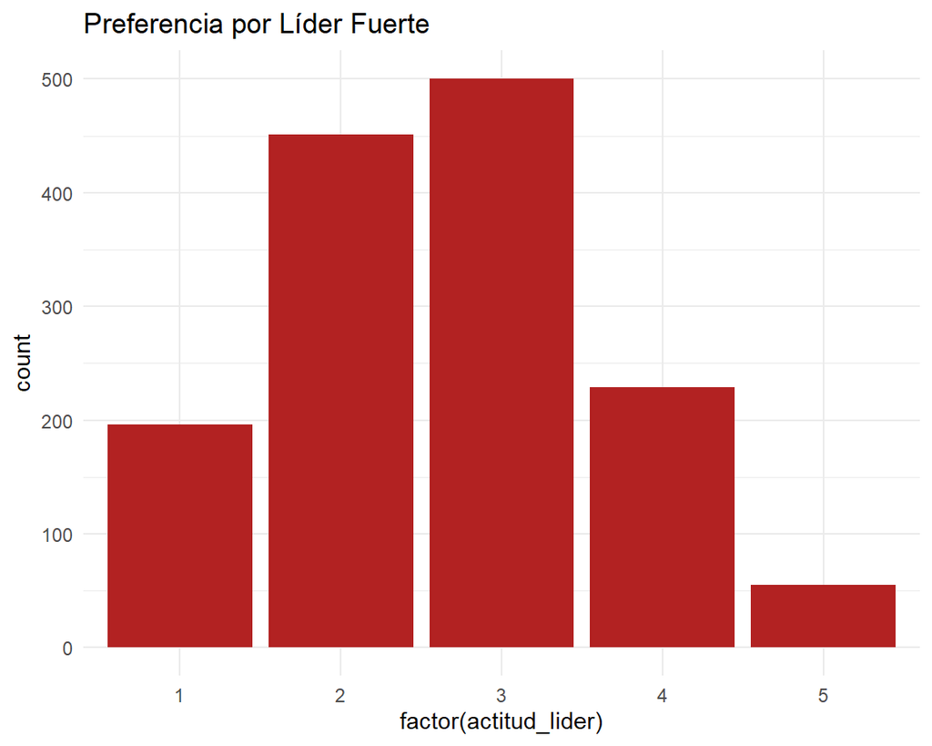

### **Cinismo Democrático**

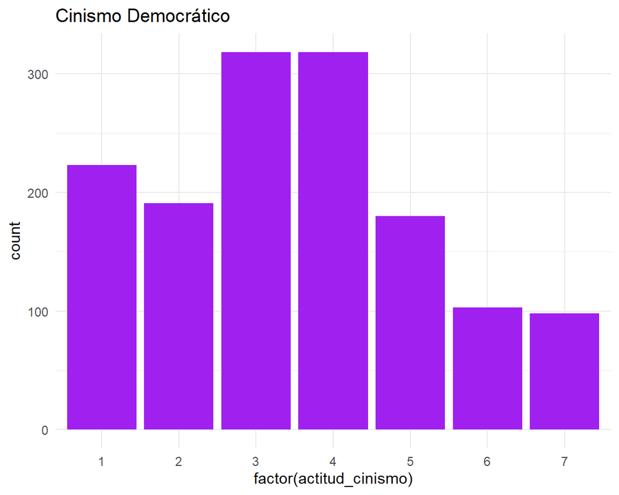

# 2. Análisis Factorial Exploratorio (AFE)

## Resultados del EFA

### **KMO**

```
[1] 0.5530019
```

### **Estructura del Factor**

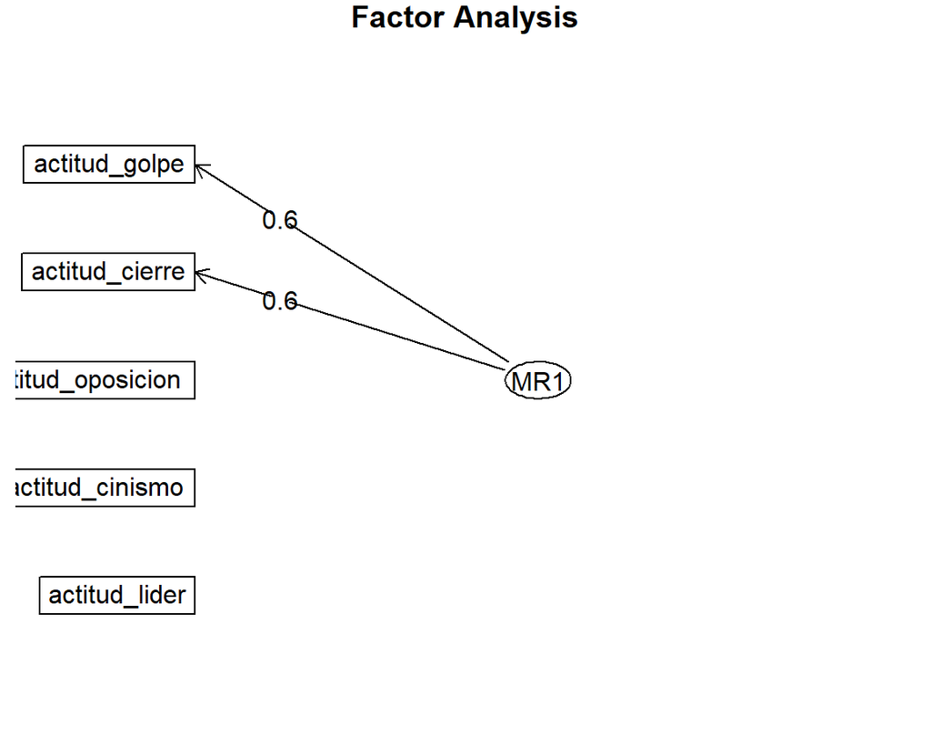

### **Distribución del Índice Autoritarismo**

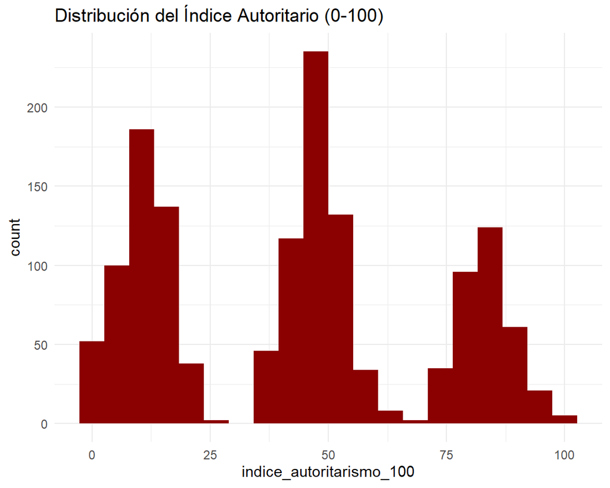

# 3. Clusters (PAM + Gower)

## Clusterización

### **Gráfico de Siluetas**

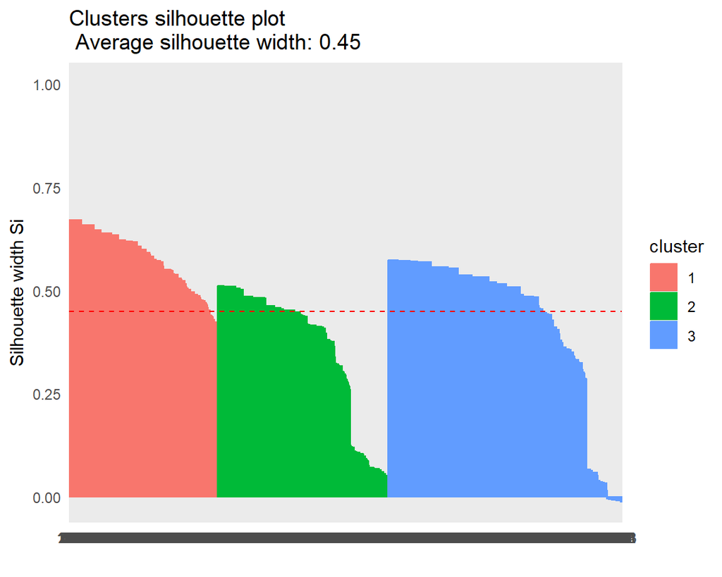

### **Perfiles de Cada Cluster**

Perfiles de los Clusters

| Cluster | N | Autoritarismo_Promedio | Pct_Apoyo_Golpe | Pct_Prioriza_Seguridad |
| --- | --- | --- | --- | --- |
| 1 | 385 | 47.3 | 100% | 16.1% |
| 2 | 441 | 76.5 | 78% | 11.8% |
| 3 | 605 | 15.5 | 0% | 10.9% |

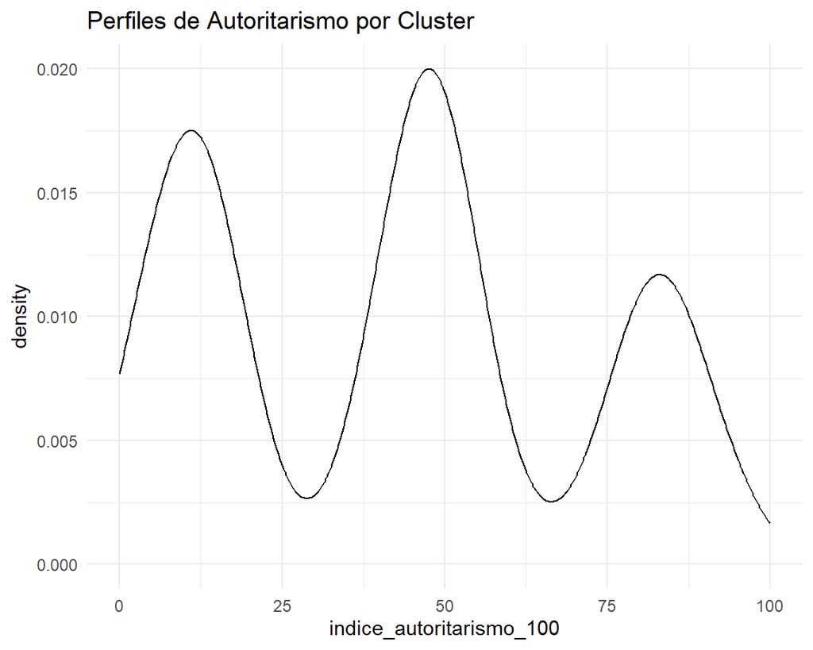

# 4. Modelos de Regresión (Logística)

## Comparación de Modelos

### **Tabla de Odds Ratios**

Odds Ratios

|  | Modelo 1 | Modelo 2 (+Socio) | Modelo 3 (+Contexto) |
| --- | --- | --- | --- |
| (Intercept) | 1.246 | 1.715927e+28 | 2.758633e+28 |
|  | [1.115, 1.393] | [6.294436e+12, 6.151985e+43] | [8.489952e+12, 1.190538e+44] |
| prioriza_seguridad | 1.232 | 1.276000e+00 | 1.224000e+00 |
|  | [0.898, 1.701] | [9.100000e-01, 1.801000e+00] | [8.690000e-01, 1.734000e+00] |
| mujer |  | 9.120000e-01 | 9.130000e-01 |
|  |  | [7.290000e-01, 1.140000e+00] | [7.280000e-01, 1.144000e+00] |
| educacion |  | 9.520000e-01 | 9.470000e-01 |
|  |  | [8.680000e-01, 1.043000e+00] | [8.630000e-01, 1.038000e+00] |
| ingresos |  | 9.430000e-01 | 9.430000e-01 |
|  |  | [9.130000e-01, 9.740000e-01] | [9.120000e-01, 9.740000e-01] |
| victima_crimen |  |  | 1.284000e+00 |
|  |  |  | [1.006000e+00, 1.642000e+00] |
| miedo_barrio |  |  | 1.074000e+00 |
|  |  |  | [9.520000e-01, 1.212000e+00] |
| Num.Obs. | 1431 | 1336 | 1330 |
| AIC | 1964.7 | 1819.4 | 1809.3 |
| BIC | 1975.2 | 1845.4 | 1845.7 |
| Log.Lik. | -980.336 | -904.710 | -897.669 |
| F | 1.645 | 5.992 | 4.962 |
| RMSE | 0.50 | 0.49 | 0.49 |

### **Forest Plot**

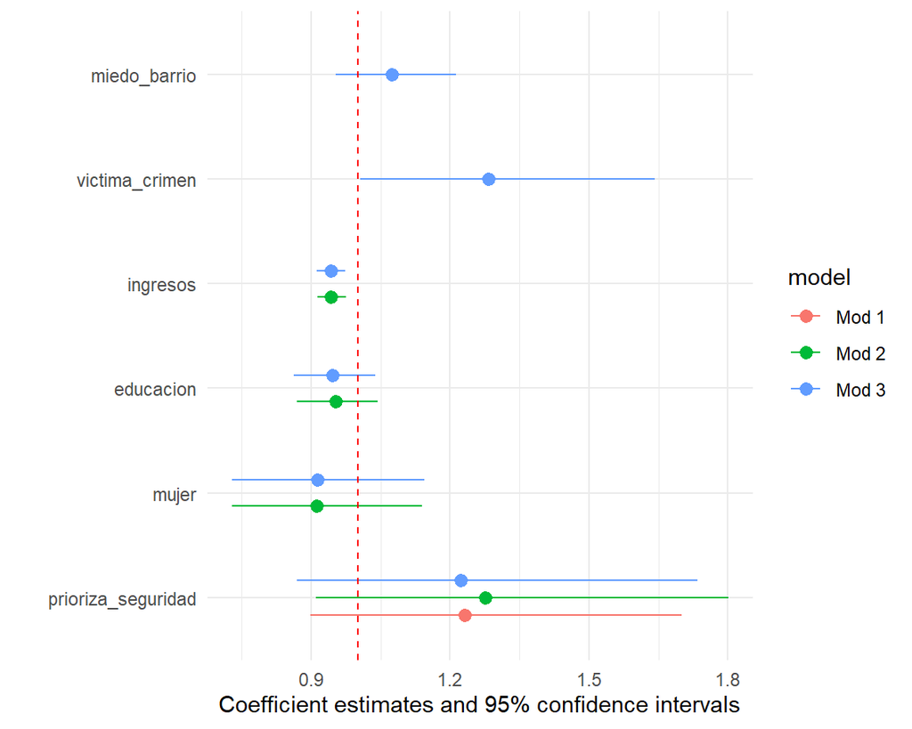

### **Comparación de AIC**

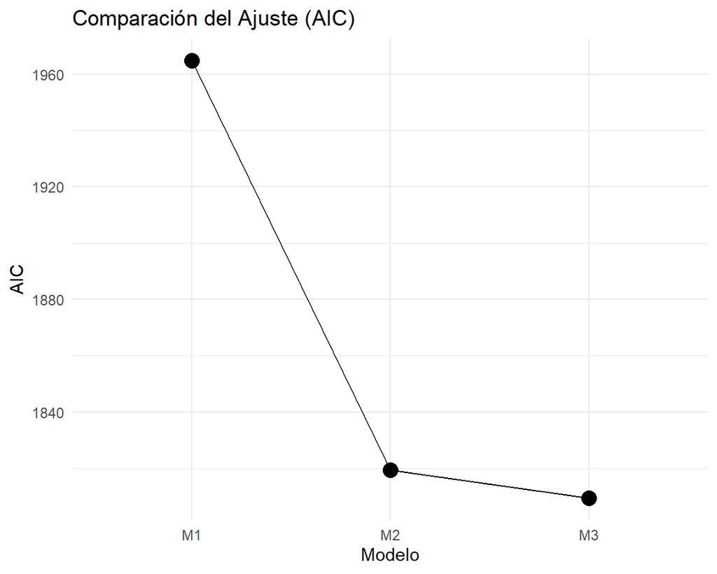